# **FoodHub Data Analysis**

## **Context**

The number of restaurants in **New York** is growing rapidly, catering to the increasing demand from **students and busy professionals** who rely on food delivery due to their hectic lifestyles. **Online food delivery services** offer a convenient solution, providing access to a variety of restaurants with just a few taps on a smartphone.

**FoodHub**, a food aggregator platform, connects customers with multiple restaurants through a single mobile app. The app streamlines the food ordering and delivery process:

1. Customers place an order through the app.
2. The restaurant receives the order and confirms it.
3. A delivery person is assigned to pick up the order once it is ready.
4. The delivery person collects the food and delivers it to the customer's location.
5. The customer receives the order and can provide a rating in the app.

FoodHub earns revenue by charging a **fixed margin on each delivery order** collected from partnered restaurants.

## **Objective**

FoodHub maintains a database of **customer orders**, which contains valuable insights about **restaurant demand and customer preferences**. The company aims to analyze this data to enhance the overall customer experience and optimize business operations.

As a **Data Scientist** at FoodHub, the goal is to analyze the provided dataset and address key business questions posed by the Data Science team. The findings from this analysis will help the company make data-driven decisions to improve service efficiency and customer satisfaction.

## **Data Description**

The dataset contains information about various food orders placed through the FoodHub platform. Below is a detailed description of the dataset:

### **Data Dictionary**

| **Feature** | **Description** |
| --- | --- |
| **order_id** | Unique identifier for each order |
| **customer_id** | ID of the customer who placed the order |
| **restaurant_name** | Name of the restaurant from which the order was placed |
| **cuisine_type** | Type of cuisine ordered by the customer |
| **cost** | Total cost of the order |
| **day_of_the_week** | Indicates whether the order was placed on a **weekday** (Monday–Friday) or **weekend** (Saturday–Sunday) |
| **rating** | Customer rating for the order (out of 5) |
| **food_preparation_time** | Time (in minutes) taken by the restaurant to prepare the order (calculated from order confirmation to pick-up) |
| **delivery_time** | Time (in minutes) taken by the delivery person to deliver the order (calculated from pick-up to drop-off) |

### **Importing the Required Libraries**

To begin the analysis, the necessary libraries are imported to facilitate data manipulation, visualization, and modeling.

```python
# import libraries for data manipulation
import numpy as np
import pandas as pd

# import libraries for data visualization
import matplotlib.pyplot as plt
import seaborn as sns
```

```python
import warnings
warnings.filterwarnings("ignore")
```

### **Understanding the Structure of the Data**

```python
# read the data
df = pd.read_csv('foodhub_order.csv')
# returns the first 5 rows
df.head()
```

|  | order_id | customer_id | restaurant_name | cuisine_type | cost_of_the_order | day_of_the_week | rating | food_preparation_time | delivery_time |
| --- | --- | --- | --- | --- | --- | --- | --- | --- | --- |
| 0 | 1477147 | 337525 | Hangawi | Korean | 30.75 | Weekend | Not given | 25 | 20 |
| 1 | 1477685 | 358141 | Blue Ribbon Sushi Izakaya | Japanese | 12.08 | Weekend | Not given | 25 | 23 |
| 2 | 1477070 | 66393 | Cafe Habana | Mexican | 12.23 | Weekday | 5 | 23 | 28 |
| 3 | 1477334 | 106968 | Blue Ribbon Fried Chicken | American | 29.20 | Weekend | 3 | 25 | 15 |
| 4 | 1478249 | 76942 | Dirty Bird to Go | American | 11.59 | Weekday | 4 | 25 | 24 |

The DataFrame has 9 columns as mentioned in the Data Dictionary. Data in each row corresponds to the order placed by a customer.

### **Dataset Dimensions**

The total number of rows and columns in the dataset is determined to understand its overall structure. This provides an overview of the dataset's size before proceeding with further analysis.

```python
# Displays the dimensions of the dataframe (number of rows and columns)
df.shape
```

```
(1898, 9)
```

There are 1898 rows and 9 columns in this dataframe.

### **Examining Data Types of Columns**

The dataset's columns are analyzed to determine their respective data types. This helps in understanding the structure of the data and identifying any necessary transformations required for further analysis. The `info()` function is utilized for this purpose.

```python
# Use info() to print a concise summary of the DataFrame
df.info()
```

```
<class 'pandas.core.frame.DataFrame'>
RangeIndex: 1898 entries, 0 to 1897
Data columns (total 9 columns):
 #   Column                 Non-Null Count  Dtype
---  ------                 --------------  -----
 0   order_id               1898 non-null   int64
 1   customer_id            1898 non-null   int64
 2   restaurant_name        1898 non-null   object
 3   cuisine_type           1898 non-null   object
 4   cost_of_the_order      1898 non-null   float64
 5   day_of_the_week        1898 non-null   object
 6   rating                 1898 non-null   object
 7   food_preparation_time  1898 non-null   int64
 8   delivery_time          1898 non-null   int64
dtypes: float64(1), int64(4), object(4)
memory usage: 133.6+ KB
```

The columns order_id, customer_id, cost_of_the_order, food_preparation_time, and delivery_time are numeric, while restaurant_name, cuisine_type, day_of_the_week, and rating are categorical.

### **Handling Missing Values**

The dataset is examined for missing values across all variables. If missing values are detected, an appropriate imputation or treatment method is applied to ensure data integrity and maintain analysis accuracy.

```python
# Returns the number of missing (NaN) values in each column of the dataframe
df.isna().sum()
```

```
order_id                 0
customer_id              0
restaurant_name          0
cuisine_type             0
cost_of_the_order        0
day_of_the_week          0
rating                   0
food_preparation_time    0
delivery_time            0
dtype: int64
```

No, there is no missing value in the data.

### **Statistical Summary of Food Preparation Time**

A statistical analysis is conducted to determine the **minimum, average, and maximum time** required for food preparation after an order is placed. This provides insights into restaurant efficiency and helps identify potential delays in the order fulfillment process.

```python
# Prints the minimum, average, and maximum food preparation time
print('the minimum time it takes for food to be prepared is:', df['food_preparation_time'].min())
print('the average time it takes for food to be prepared is:', df['food_preparation_time'].mean())
print('the maximum time it takes for food to be prepared is:', df['food_preparation_time'].max())
```

```
the minimum time it takes for food to be prepared is: 20
the average time it takes for food to be prepared is: 27.371970495258168
the maximum time it takes for food to be prepared is: 35
```

### **Identifying Unrated Orders**

The total number of orders that have not been rated by customers is determined to understand the proportion of missing ratings in the dataset. This helps assess customer engagement with the rating system and its potential impact on business insights.

```python
# Displays the count of each unique value in the 'rating' column, including 'Not given' ratings (NaN values)
df['rating'].value_counts(dropna=False)
```

```
rating
Not given    736
5            588
4            386
3            188
Name: count, dtype: int64
```

```python
# Counts the number of orders where the 'rating' is 'Not given' and stores the result in 'not_rated'
not_rated = df.loc[df['rating']=='Not given', 'order_id'].count()
```

```python
print('There are', not_rated, 'orders which are not rated')
```

```
There are 736 orders which are not rated
```

### Exploratory Data Analysis (EDA)

### **Exploring Variable Distributions**

A detailed exploration of all variables is conducted to analyze their distributions and identify patterns or trends in the data. Observations based on these distributions provide insights into customer behavior, order patterns, and potential factors influencing the business.

```python
# Displays the first 5 rows of the DataFrame to give a quick overview of the data
df.head()
```

|  | order_id | customer_id | restaurant_name | cuisine_type | cost_of_the_order | day_of_the_week | rating | food_preparation_time | delivery_time |
| --- | --- | --- | --- | --- | --- | --- | --- | --- | --- |
| 0 | 1477147 | 337525 | Hangawi | Korean | 30.75 | Weekend | Not given | 25 | 20 |
| 1 | 1477685 | 358141 | Blue Ribbon Sushi Izakaya | Japanese | 12.08 | Weekend | Not given | 25 | 23 |
| 2 | 1477070 | 66393 | Cafe Habana | Mexican | 12.23 | Weekday | 5 | 23 | 28 |
| 3 | 1477334 | 106968 | Blue Ribbon Fried Chicken | American | 29.20 | Weekend | 3 | 25 | 15 |
| 4 | 1478249 | 76942 | Dirty Bird to Go | American | 11.59 | Weekday | 4 | 25 | 24 |

```python
# Counts the occurrences of each unique value in the 'cuisine_type' column
df['cuisine_type'].value_counts()
```

```
cuisine_type
American          584
Japanese          470
Italian           298
Chinese           215
Mexican            77
Indian             73
Middle Eastern     49
Mediterranean      46
Thai               19
French             18
Southern           17
Korean             13
Spanish            12
Vietnamese          7
Name: count, dtype: int64
```

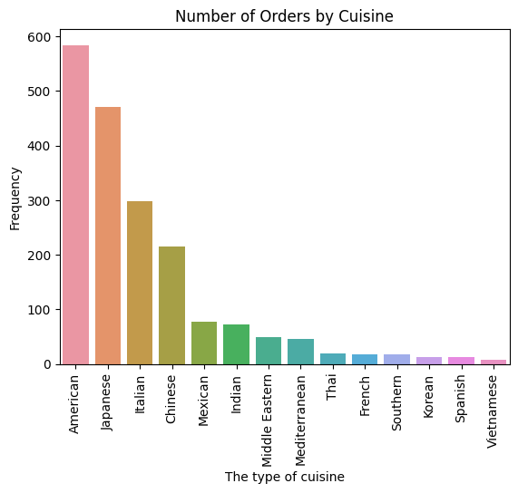

```python
# Creates a count plot to visualize the number of orders for each cuisine type
sns.countplot(x= df['cuisine_type'], order=df['cuisine_type'].value_counts().index)
# Sets the title of the plot
plt.title('Number of Orders by Cuisine')
# Labels the x-axis
plt.xlabel('The type of cuisine')
# Labels the y-axis
plt.ylabel('Frequency')
# Rotates the x-axis labels by 90 degrees for better readability
plt.xticks(rotation=90)
# Displays the plot
plt.show()
```

It seems that American is the most popular cuisine among all. The popularity of American cuisine can reflect cultural preferences or ease of availability in our dataset's geographical region.

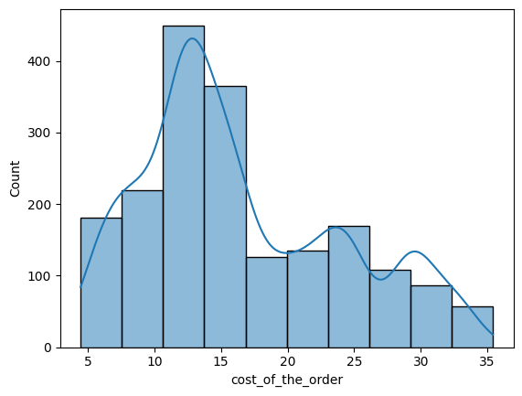

```python
# Creates a histogram with 10 bins and overlays a kernel density estimate (KDE) for the distribution of the 'cost_of_the_order' column
sns.histplot(df['cost_of_the_order'], bins= 10, kde = True)
```

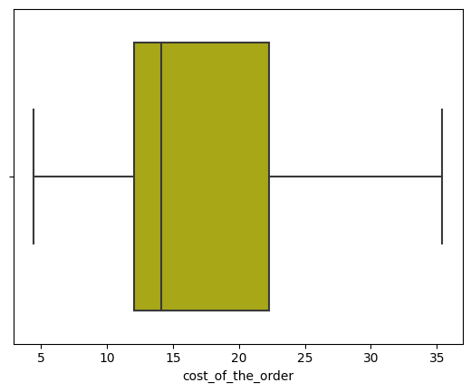

```python
# Creates a boxplot for the 'cost_of_the_order' column with the color yellow ('y')
sns.boxplot(data=df, x='cost_of_the_order', color= 'y')
```

Right skewness for cost of orders sgows that most of the orders have relatively lower costs. There are some high-cost orders, which stretch the distribution to the right.

```python
# Counts the number of occurrences for each unique value in the 'day_of_the_week' column
df['day_of_the_week'].value_counts()
```

```
day_of_the_week
Weekend    1351
Weekday     547
Name: count, dtype: int64
```

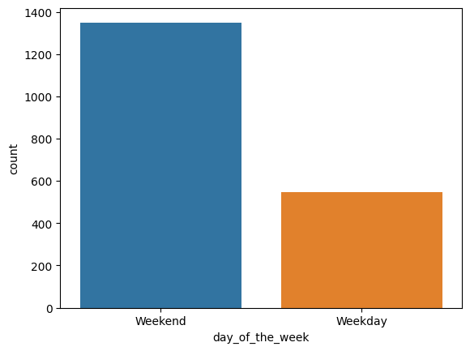

```python
# Plots a countplot to show the frequency of each value in the 'day_of_the_week' column
sns.countplot(data =df, x='day_of_the_week')
```

Based on the plot and the calculation, the orders are way more on weekends than weekdays. It seems that people are likely placing more orders on weekends due to leisure time, events, or weekend specials. So, we should plan for higher demand during weekends (e.g., drivers). In addition, introducing promotions on weekdays can balance the load.

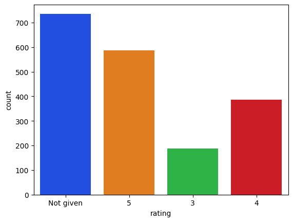

```python
# Plots a countplot to show the frequency of each rating value in the 'rating' column, using a bright color palette
sns.countplot(data= df, x = 'rating', palette = 'bright')
```

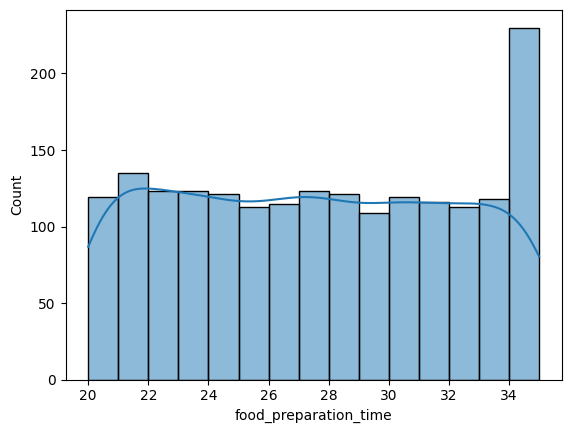

```python
# Plots a histogram to show the distribution of 'food_preparation_time' with 15 bins and overlays a Kernel Density Estimate (KDE)
sns.histplot(df['food_preparation_time'], bins= 15, kde = True)
```

The histogram of food preparation time shows that it may have a uniform distribution, the only exception is the bing toward the max of the range which has comparably higher volume.

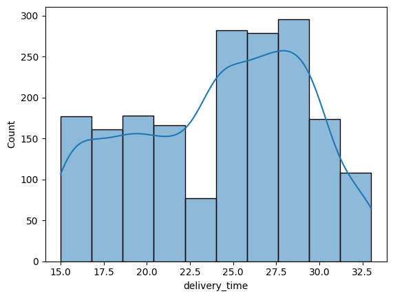

```python
# Plots a histogram to show the distribution of 'delivery_time' with 10 bins and overlays a Kernel Density Estimate (KDE)
sns.histplot(df['delivery_time'], bins= 10, kde = True)
```

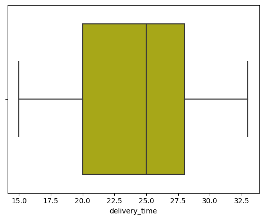

```python
# Creates a boxplot to visualize the distribution and potential outliers of 'delivery_time', with yellow color ('y')
sns.boxplot(data=df, x='delivery_time', color= 'y')
```

Based on these two charts, the delivery time has a smaller Q3 section, indicating that the values between the 50th and 75th percentiles are more concentrated (less variable) compared to other parts of the dataset.

### **Top 5 Restaurants by Order Volume**

The dataset is analyzed to identify the **top 5 restaurants** that have received the highest number of orders. This provides insights into customer preferences and helps in understanding which restaurants are the most popular on the platform.

```python
# Groups the data by 'restaurant_name', counts the number of orders ('order_id') for each restaurant,
# sorts them in descending order, and selects the top 5 restaurants with the most orders.
df.groupby(['restaurant_name'])['order_id'].count().sort_values(ascending=False).head(5).index
```

```
Index(['Shake Shack', 'The Meatball Shop', 'Blue Ribbon Sushi',
       'Blue Ribbon Fried Chicken', 'Parm'],
      dtype='object', name='restaurant_name')
```

So, the five top restaurant in terms of the number of orders are: "Shake Shack", "The Meatball Shop", "Blue Ribbon Sushi", "Blue Ribbon Fried Chicken", and "Parm".

### **Most Popular Cuisine on Weekends**

The dataset is analyzed to determine which **cuisine type** is ordered the most on weekends. Identifying popular weekend cuisines helps in understanding customer preferences and can assist in optimizing restaurant offerings and promotions.

```python
# Filters the dataset to only include rows where 'day_of_the_week' is 'Weekend',
# then counts the occurrences of each 'cuisine_type',
# and returns the cuisine type with the highest count (most popular on weekends).
df.loc[df['day_of_the_week']=='Weekend']['cuisine_type'].value_counts(dropna=False).idxmax()
```

```
'American'
```

American cuisine is the most popular over the weekend.

### **Percentage of Orders Above $20**

The dataset is analyzed to determine the **percentage of orders** that cost more than **$20**. This provides insights into customer spending behavior and helps in understanding the distribution of order costs on the platform.

```python
# Filters the dataset to include only rows where 'cost_of_the_order' is greater than 20,
# counts the number of such orders ('order_id'),
# and then divides this count by the total number of rows in the dataset (df.shape[0])
# to calculate the proportion of orders with a cost greater than 20.
df.loc[df['cost_of_the_order']>20, 'order_id'].count() / df.shape[0]
```

```
0.2924130663856691
```

### **Average Order Delivery Time**

The dataset is analyzed to calculate the **mean delivery time** for orders. This provides insights into the efficiency of the delivery process and helps in identifying potential areas for improvement.

```python
# Calculates the mean (average) of the 'delivery_time' column in the dataframe.
df['delivery_time'].mean()
```

```
24.161749209694417
```

The mean order delivery time is 24.16 minutes.

### **Identifying Top 3 Frequent Customers for Discount Vouchers**

To reward customer loyalty, the dataset is analyzed to identify the **top 3 most frequent customers** based on the number of orders placed. Their **customer IDs** and **order counts** are determined to issue **20% discount vouchers** as part of the company's promotional strategy.

```python
# Groups the dataframe by 'customer_id', counts the number of orders for each customer,
# sorts the counts in descending order, and then returns the top 3 customers with the most orders.
df.groupby(['customer_id'])['order_id'].count().sort_values(ascending=False).head(3)
```

```
customer_id
52832    13
47440    10
83287     9
Name: order_id, dtype: int64
```

The most frequent customer ids are 52832, 47440 and 83287 which have 13, 10, and 9 orders respectively.

### **Multivariate Analysis of Key Variables**

A **multivariate analysis** is conducted to explore relationships between important variables in the dataset. This includes analyzing interactions between **numerical variables** and examining dependencies between **numerical and categorical variables**. Identifying these relationships helps in uncovering patterns, trends, and potential insights that can improve business decisions.

First, let's check if there is any relationship between the numerical variables

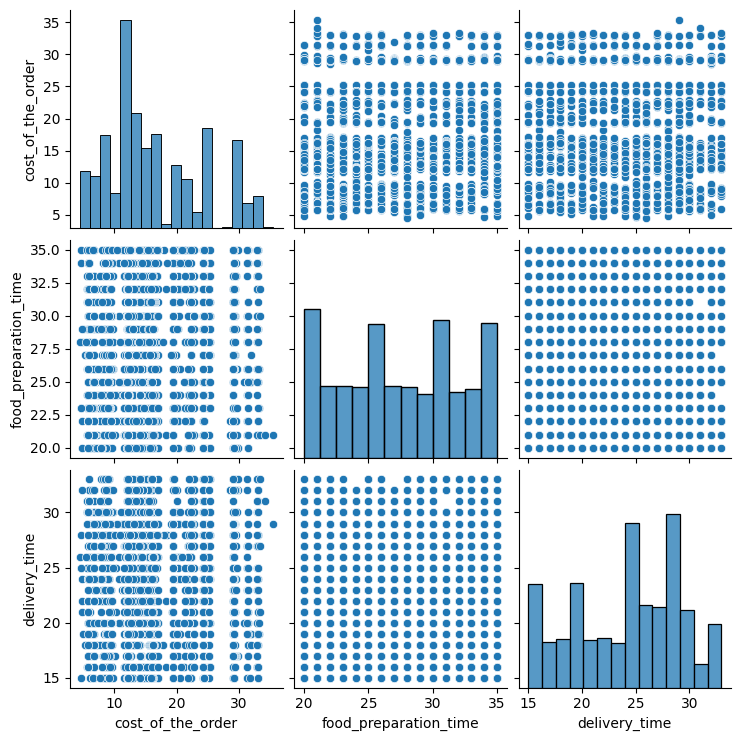

```python
# Creates a pairplot to visualize relationships between 'cost_of_the_order', 'food_preparation_time', and 'delivery_time'
sns.pairplot(df[['restaurant_name', 'cuisine_type',
       'cost_of_the_order', 'day_of_the_week', 'rating',
       'food_preparation_time', 'delivery_time']])
plt.show()
```

It seems that there is no obvoius relationship between the "delivery_time", "food_preparation_time" and "cost_of_the_order"!. In other words it seems the correlation between these variable is near 0. let's check them!

```python
# The correlation between "delivery_time", "food_preparation_time" and "cost_of_the_order":
df[["delivery_time", "food_preparation_time", "cost_of_the_order"]].corr()
```

|  | delivery_time | food_preparation_time | cost_of_the_order |
| --- | --- | --- | --- |
| delivery_time | 1.000000 | 0.011094 | -0.029949 |
| food_preparation_time | 0.011094 | 1.000000 | 0.041527 |
| cost_of_the_order | -0.029949 | 0.041527 | 1.000000 |

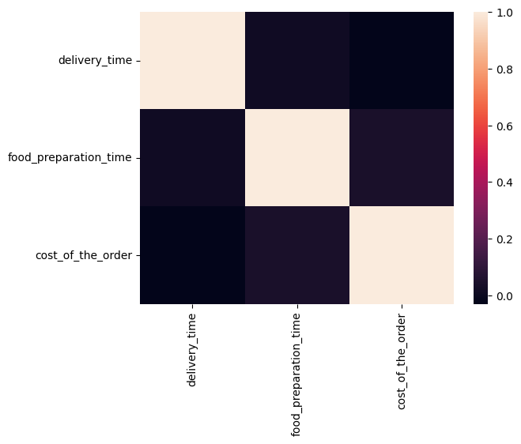

```python
# Creates a heatmap to visualize the correlation matrix between 'delivery_time', 'food_preparation_time', and 'cost_of_the_order'.
sns.heatmap(df[["delivery_time", "food_preparation_time", "cost_of_the_order"]].corr())
```

As mentioned before, the correlation between "delivery_time", "food_preparation_time", and "cost_of_the_order" variable are near 0.

Now, we want to check the relationships between numerical and categorical variables.

```python
# Displays the list of column names in the DataFrame
df.columns
```

```
Index(['order_id', 'customer_id', 'restaurant_name', 'cuisine_type',
       'cost_of_the_order', 'day_of_the_week', 'rating',
       'food_preparation_time', 'delivery_time'],
      dtype='object')
```

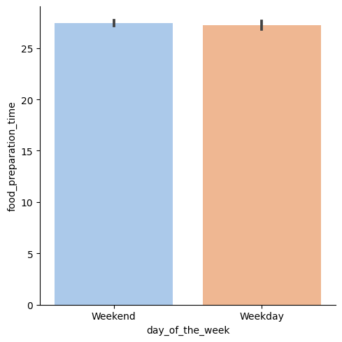

```python
# Creates a bar plot to compare the food preparation time across different days of the week.
sns.catplot(data =df, x='day_of_the_week', y='food_preparation_time', kind='bar', palette = 'pastel')
```

It looks like there is no signifacant difference in food preparation time based on whether the order is on weekdays or weekends.

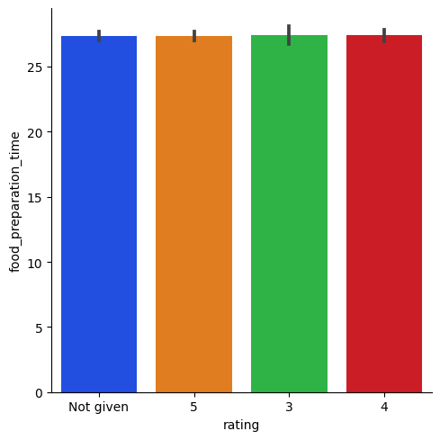

```python
# Creates a bar plot to compare food preparation time based on different ratings.
sns.catplot(data =df, x='rating', y='food_preparation_time', kind='bar', palette = 'bright')
```

It looks like there is no signifacant difference in food preparation time based on whether it is a good rated cuisine or not.

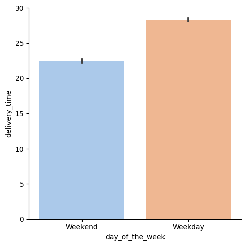

```python
# Creates a bar plot to compare delivery time based on different days of the week.
sns.catplot(data =df, x='day_of_the_week', y='delivery_time', kind='bar', palette = 'pastel')
```

The delivery time is more during the weekdays. It can be due to different factors such as traffic or having less drivers.

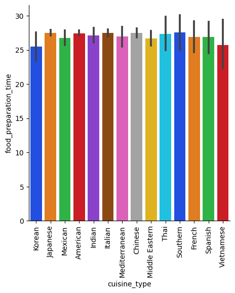

```python
# Creates a bar plot to compare food preparation time across different cuisine types.
sns.catplot(data =df, x='cuisine_type', y='food_preparation_time',kind='bar', palette = 'bright')
# Rotates the x-axis labels by 90 degrees for better readability.
plt.xticks(rotation=90)
plt.show()
```

This chart shows the variations in the average food preparation time across different types of cuisines.

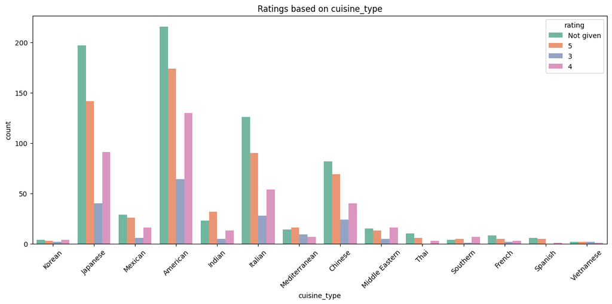

```python
# Sets the figure size for the plot to be wider for better visibility.
plt.figure(figsize=(15, 6))
# Creates a count plot to show the distribution of ratings for each cuisine type.
sns.countplot(data=df, x='cuisine_type', hue='rating', palette='Set2')
# Rotates the x-axis labels by 45 degrees for better readability.
plt.xticks(rotation=45)
# Adds a title to the plot for context.
plt.title("Ratings based on cuisine_type")
plt.show()
```

This plot allows us to compare the count of different ratings (3, 4, 5, and 'Not given') across various types of cuisines.

```python
# Filters the dataset to exclude rows where the rating is 'Not given'.
filtered_df = df[df['rating'] != 'Not given']
# Converts the 'rating' column to integer type for numerical operations.
filtered_df['rating']= filtered_df['rating'].astype(int)
# Groups the filtered data by 'cuisine_type' and calculates the mean and count of ratings for each cuisine type.
filtered_df.groupby('cuisine_type')['rating'].agg(['mean', 'count'])
```

| cuisine_type | mean | count |
| --- | --- | --- |
| American | 4.298913 | 368 |
| Chinese | 4.338346 | 133 |
| French | 4.300000 | 10 |
| Indian | 4.540000 | 50 |
| Italian | 4.360465 | 172 |
| Japanese | 4.373626 | 273 |
| Korean | 4.111111 | 9 |
| Mediterranean | 4.218750 | 32 |
| Mexican | 4.416667 | 48 |
| Middle Eastern | 4.235294 | 34 |
| Southern | 4.307692 | 13 |
| Spanish | 4.833333 | 6 |
| Thai | 4.666667 | 9 |
| Vietnamese | 4.000000 | 5 |

The above calculation presents the average rating and the number of ratings for each type of cuisine.

```python
# Groups the dataset by 'cuisine_type' and calculates the mean and count of 'food_preparation_time' for each cuisine type.
df.groupby(['cuisine_type'])['food_preparation_time'].agg(['mean', 'count'])
```

| cuisine_type | mean | count |
| --- | --- | --- |
| American | 27.440068 | 584 |
| Chinese | 27.511628 | 215 |
| French | 26.888889 | 18 |
| Indian | 27.109589 | 73 |
| Italian | 27.483221 | 298 |
| Japanese | 27.510638 | 470 |
| Korean | 25.461538 | 13 |
| Mediterranean | 27.000000 | 46 |
| Mexican | 26.727273 | 77 |
| Middle Eastern | 26.673469 | 49 |
| Southern | 27.588235 | 17 |
| Spanish | 26.916667 | 12 |
| Thai | 27.315789 | 19 |
| Vietnamese | 25.714286 | 7 |

Let's check the availability of each type of food in the restaurants

```python
# Availability of each type of cousine in the restaurants:
df.groupby('cuisine_type')['restaurant_name'].nunique()
```

```
cuisine_type
American          41
Chinese           16
French             3
Indian            14
Italian           31
Japanese          29
Korean             5
Mediterranean      5
Mexican           11
Middle Eastern     7
Southern           2
Spanish            3
Thai               9
Vietnamese         3
Name: restaurant_name, dtype: int64
```

```python
# calculates the average number of orders per restaurant for each type of cuisine
df.groupby('cuisine_type')['order_id'].count() / df.groupby('cuisine_type')['restaurant_name'].nunique()
```

```
cuisine_type
American          14.243902
Chinese           13.437500
French             6.000000
Indian             5.214286
Italian            9.612903
Japanese          16.206897
Korean             2.600000
Mediterranean      9.200000
Mexican            7.000000
Middle Eastern     7.000000
Southern           8.500000
Spanish            4.000000
Thai               2.111111
Vietnamese         2.333333
dtype: float64
```

Although American cuisine has the highest number of orders, Japanese cuisine has the highest orders per restaurant. Another interesting observation is that while Italian cuisine ranks third in total orders, Chinese restaurants experience a higher number of orders per restaurant.

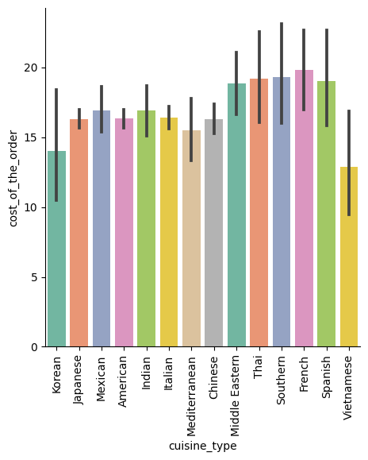

```python
# This plot shows the variation in the cost of the order for each cuisine type.
sns.catplot(data =df, x='cuisine_type', y='cost_of_the_order',kind='bar', palette = 'Set2')
# Rotates the x-axis labels for better visibility
plt.xticks(rotation=90)
plt.show()
```

This plot shows the variations in the cost of orders across different types of cuisines.

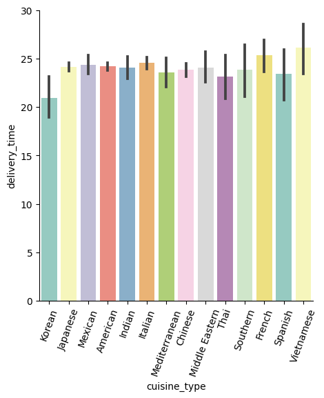

```python
# This plot shows the variation in delivery time for each cuisine type.
sns.catplot(data =df, x='cuisine_type', y='delivery_time',kind='bar', palette = 'Set3')
plt.xticks(rotation=70)
plt.show()
```

This plot illustrates how delivery times vary for each cuisine type.

### **Identifying Restaurants Eligible for Promotional Offers**

To enhance restaurant visibility, the company plans to provide a **promotional offer** in advertisements. Restaurants must meet the following criteria to qualify:

- Have received **more than 50 ratings**
- Maintain an **average rating greater than 4**

The dataset is analyzed to identify the restaurants that fulfill these conditions and are eligible for the promotional offer.

```python
# Filter the data to exclude rows where the rating is 'Not given'
filtered_df = df[df['rating'] != 'Not given']
# Convert the 'rating' column to integers
filtered_df['rating']= filtered_df['rating'].astype(int)
# Group the data by 'restaurant_name' and calculate the mean and count of ratings for each restaurant
grouped = filtered_df.groupby('restaurant_name')['rating'].agg(['mean', 'count'])
# Filter restaurants where the average rating is greater than 4 and the count of ratings is greater than 50
grouped[(grouped['mean']>4) & (grouped['count']>50)]
```

| restaurant_name | mean | count |
| --- | --- | --- |
| Blue Ribbon Fried Chicken | 4.328125 | 64 |
| Blue Ribbon Sushi | 4.219178 | 73 |
| Shake Shack | 4.278195 | 133 |
| The Meatball Shop | 4.511905 | 84 |

The restaurants with rating count of more than 50 and the average rating greater than 4 are: Blue Ribbon Fried Chicken, Blue Ribbon Sushi, Shake Shack, and The Meatball Shop

### **Calculating Net Revenue Generated by the Company**

The company applies a **tiered commission structure** based on order cost:

- **25% commission** on orders costing more than **$20**
- **15% commission** on orders costing more than **$5**

The dataset is analyzed to compute the **total revenue** generated from all orders based on this commission structure.

```python
# Find the minimum value in the 'cost_of_the_order' column
df['cost_of_the_order'].min()
```

```
4.47
```

```python
# Calculate the net revenue based on the cost of the order
df['net_revenue'] = df['cost_of_the_order'].apply(lambda x: x*0.25 if x>20 else (x*0.15 if x>5 else 0))
```

```python
# Calculate the total net revenue
df['net_revenue'].sum()
```

```
6166.303
```

The net revenue generated by the company across all orders is 6166.303.

### **Analyzing Total Delivery Time**

The company aims to assess the **total time required** for food delivery, which includes both **preparation time** and **delivery time**.

To evaluate efficiency, the dataset is analyzed to determine **the percentage of orders that take more than 60 minutes** from the time the order is placed until it is delivered to the customer.

```python
# Create a new column 'total_time' that is the sum of 'food_preparation_time' and 'delivery_time'
df['total_time'] = df['food_preparation_time'] + df['delivery_time']
```

```python
# Calculate the proportion of orders with a total time greater than 60 minutes
df.loc[df['total_time']>60]['order_id'].count() / df.shape[0]
```

```
0.1053740779768177
```

10.54 of orders take more than 60 minutes to get delivered from the time the order is placed

### **Analyzing Delivery Time on Weekdays vs. Weekends**

To assess delivery efficiency, the company aims to compare the **mean delivery time** for orders placed on **weekdays** versus **weekends**.

The dataset is analyzed to determine if there are any significant variations in delivery times based on the day of the week.

```python
# Calculate the average delivery time for each group in day_of_the_week column
df.groupby(['day_of_the_week'])['delivery_time'].mean()
```

```
day_of_the_week
Weekday    28.340037
Weekend    22.470022
Name: delivery_time, dtype: float64
```

The mean delivery time for Weekday are 28.34 and 22.47 during weekdays and weekends respectively.

### Conclusion and Recommendations

### **Conclusions and Business Recommendations**

Based on the analysis, key insights are derived to understand customer preferences, order trends, and operational efficiency.

### Conclusions:

- American cuisine is the most popular among all.
- Orders are significantly higher on weekends than on weekdays.
- A large portion of the ratings column consists of "Not given" values.
- Delivery times are longer during weekdays.
- The ratings start at 3, with no 1 or 2 values present in the ratings column.

### Recommendations:

- Address Missing Ratings: Since there are no ratings of 1 or 2 and many entries are marked as "Not given," investigate whether dissatisfied customers are opting not to provide ratings. Consider replacing numerical ratings with simpler feedback options, such as a thumbs-up or thumbs-down system, to encourage participation.
- Increase Weekday Orders: Explore why orders are lower on weekdays. Could this be due to a lack of convenience for people ordering while at work? Simplifying the ordering process or offering promotions during weekdays could help balance the order volume and drive more sales.
- Focus on Cuisine-Specific Strategies: While there are more restaurants offering American cuisine, Japanese restaurants have a higher number of orders per restaurant. Similarly, while Italian restaurants rank third in total orders, Chinese restaurants have a higher order count per establishment. This suggests the potential for increasing the number of restaurants offering Japanese cuisine or diversifying the restaurant options to improve the overall success of the app.